# Econometrics_lab

**Состав команды:**

Ляпина Екатерина, Дмитрий Гайдаржи

Для анализа были взяты следующие данные, предоставленные преподавателем в рамках курса эконометрики в ВШЭ. Загружаем необходимые для исследования пакеты и данные из файла.

```r
# Esli russkie bukvi prevratilitis v krakozyabry,
# to File - Reopen with encoding... - UTF-8 - Set as default - OK


#install.packages("foreign")
library("foreign") # конвертация файлов Stata
#install.packages("dplyr")
library("dplyr") # манипуляции с данными
#install.packages("erer")
library("erer") # расчет предельных эффектов
#install.packages("vcd")
library("vcd") # графики для качественных данных
#install.packages("ggplot2")
library("ggplot2") # графики
#install.packages("reshape2")
library("reshape2") # манипуляции с данными
#install.packages("AUC")
library("AUC") # для ROC кривой


# читаем данные
women <- read.dta("womenwk_data.dta")
```

**Объектом исследования** является занятость слабого пола.

**Предметом исследования** выступают причинно-следственные связи и зависимости экономических и социальных показателей, сформированных в результате деятельсноти женщины.

**Цель работы:**

Выяснить, какие факторы могут влиять на выбор женщины работать – не работать.

**Задачи:**

Прохождение этапов извлечения, очистки и трансформации сырых данных. Использование разных методик и средств математической статистики для построения модели. Практическая задача сводится к необходимости выявления, в какой степени какие факторы определяют занятость женщин и почему.

# Описание данных:

В нашем наборе данных 2000 наблюдений и 6 переменных. Исходный файл с данными в формате dat (формат Stata).

### Описание исходных переменных:

- **age**: возраст, в годах.
- **education** : число полных лет обучения, в годах.
- **married** : состояние в браке (1 – если состоит, 0 – иначе).
- **children** : наличие детей (порядковая переменная, принимает значения от 0 до 5).
- **wagefull** : годовой доход женщины, тыс. долл.
- **wage** : годовой доход работающей женщины, тыс. долл.

Сначала необходимо сгенерировать зависимую переменную work. Она принимает значение 1, если женщина работает, и 0 – если не работает. Для создания этой переменной выполняем следующие действия:

```r
# при загрузке файлов R автоматом переделывает все строковые переменные в факторные, просим R так не делать
options(stringsAsFactors=FALSE)

#создаем переменную work
for (i in 1:nrow(women)) women[i,7]  = ifelse(women[i,5]==women[i,6], 1, 0)
for (i in 1:nrow(women)) women[i,7]  = ifelse(is.na(women[i,7]), 0, 1)
names(women) <- c("age","education","married", "children","wagefull","wage", "work")

# объясняем R, какие переменные считать факторными
women <- mutate(women,married=as.factor(married),work=as.factor(work))
```

Рассчитаем описательные характеристики:

```r
knitr::kable(summary(women))
```

|  | age | education | married | children | wagefull | wage | work |
| --- | --- | --- | --- | --- | --- | --- | --- |
|  | Min. :20.00 | Min. :10.00 | 0: 659 | Min. :0.000 | Min. :-1.68 | Min. : 5.885 | 0: 657 |
|  | 1st Qu.:30.00 | 1st Qu.:10.00 | 1:1341 | 1st Qu.:1.000 | 1st Qu.:16.46 | 1st Qu.:19.316 | 1:1343 |
|  | Median :36.00 | Median :12.00 | NA | Median :1.000 | Median :21.18 | Median :23.511 | NA |
|  | Mean :36.21 | Mean :13.08 | NA | Mean :1.645 | Mean :21.31 | Mean :23.692 | NA |
|  | 3rd Qu.:42.00 | 3rd Qu.:16.00 | NA | 3rd Qu.:3.000 | 3rd Qu.:26.14 | 3rd Qu.:28.035 | NA |
|  | Max. :59.00 | Max. :20.00 | NA | Max. :5.000 | Max. :45.81 | Max. :45.810 | NA |
|  | NA | NA | NA | NA | NA | NA’s :657 | NA |

Также построим пару графиков, для того, чтобы лучше понимать, с чем мы имеем дело: мозаичный график, график-виолончель, “ящик с усами” и 2 варианты сглаженной функции плотности для зависимости занятости от возраста и образования.

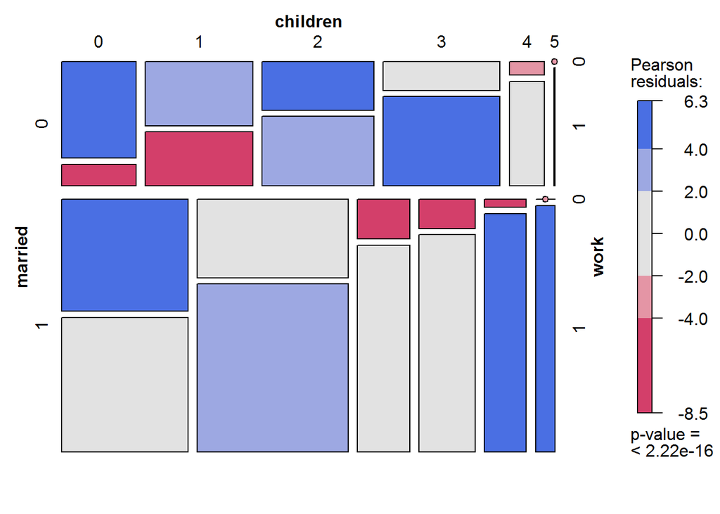

```r
# мозаичный график
mosaic(data=women,~married+children+work,shade=TRUE)
```

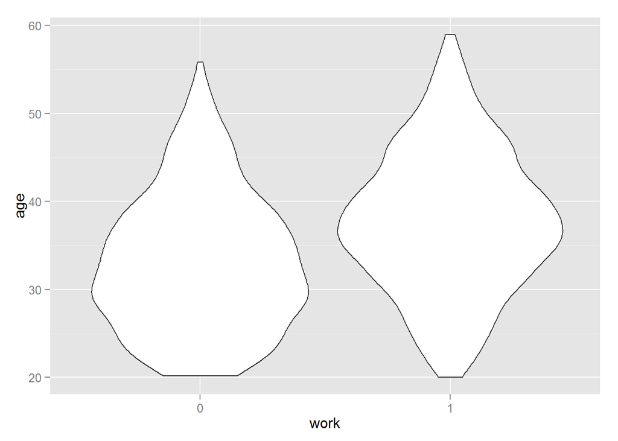

```r
# график-виолончель
qplot(data=women,x=work,y=age,geom="violin")
```

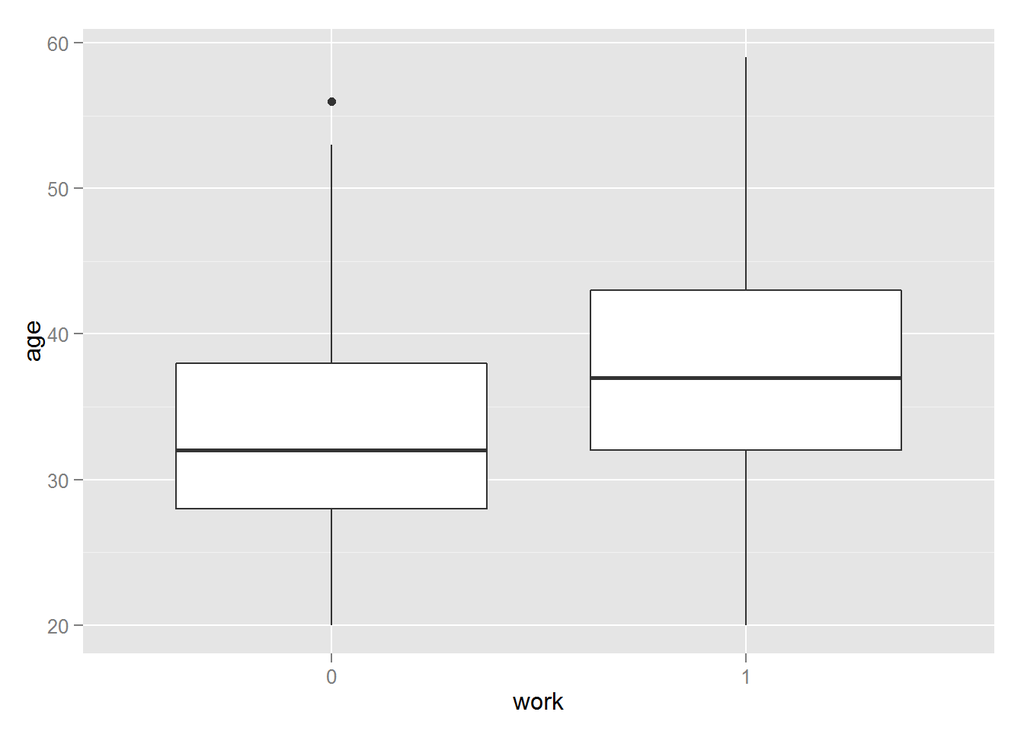

```r
# и "ящик с усами"
qplot(data=women,x=work,y=age,geom="boxplot")
```

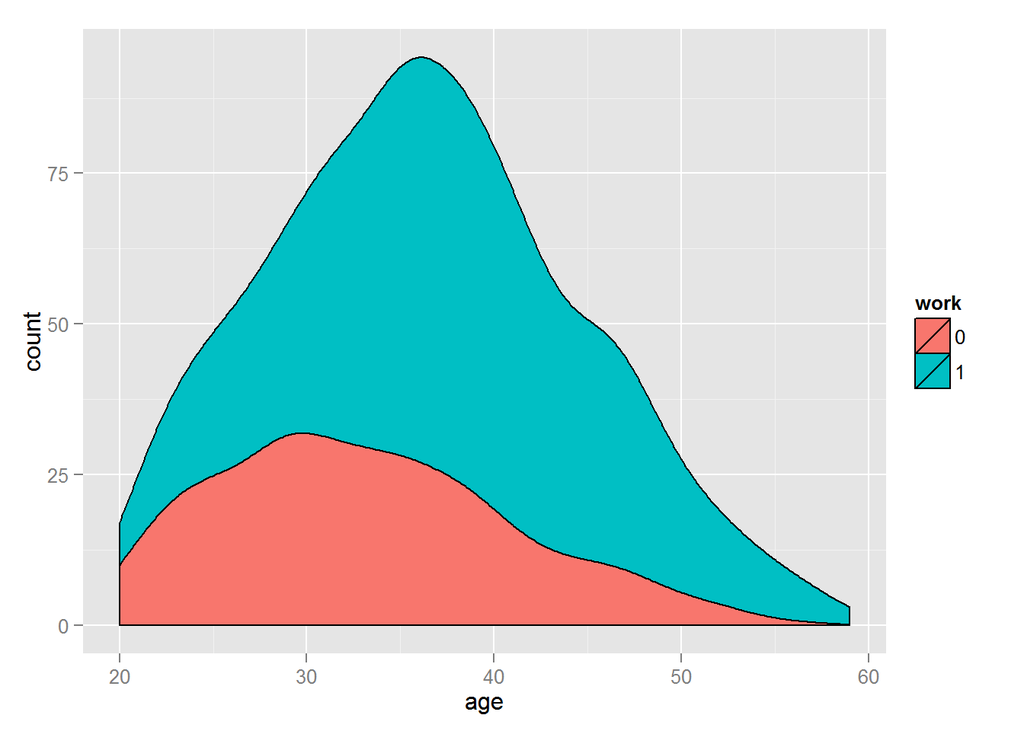

```r
#сглаженная функция плотности от возраста
qplot(data=women,x=age,y=..count..,fill=work,geom="density",position="stack")
```

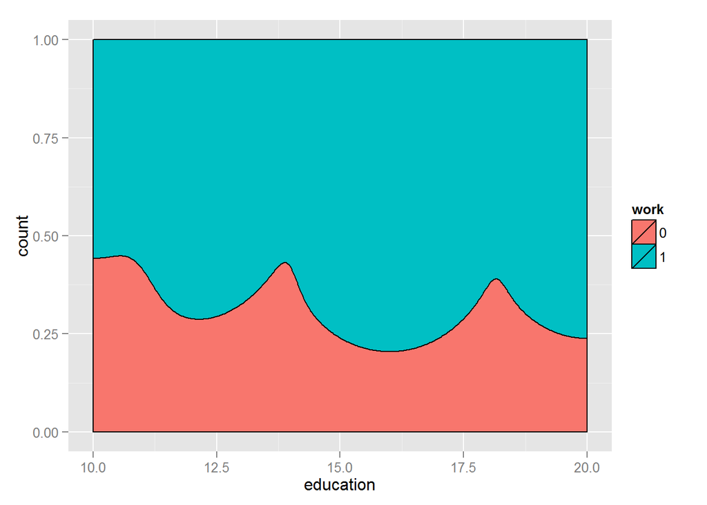

```r
#сглаженная функция плотности от щбразования
qplot(data=women,x=education,y=..count..,fill=work,geom="density",position="fill")
```

Проведем построения логит и пробит модели исходных данных:

```r
# Построение логит и пробит моделей
m_logit <- glm(data=women, work~age + education + married + children,
               family=binomial(link="logit"),x=TRUE)
m_probit <- glm(data=women, work~age + education + married + children,
                family=binomial(link="probit"),x=TRUE)
```

Рассчитаем характеристики логит модели:

```r
summary(m_logit)
```

```
##
## Call:
## glm(formula = work ~ age + education + married + children, family = binomial(link = "logit"),
##     data = women, x = TRUE)
##
## Deviance Residuals:
##     Min       1Q   Median       3Q      Max
## -2.6212  -0.9292   0.4614   0.8340   2.0455
##
## Coefficients:
##              Estimate Std. Error z value Pr(>|z|)
## (Intercept) -4.159247   0.332040 -12.526  < 2e-16 ***
## age          0.057930   0.007221   8.022 1.04e-15 ***
## education    0.098251   0.018652   5.268 1.38e-07 ***
## married1     0.741777   0.126471   5.865 4.49e-09 ***
## children     0.764488   0.051529  14.836  < 2e-16 ***
## ---
## Signif. codes:  0 '***' 0.001 '**' 0.01 '*' 0.05 '.' 0.1 ' ' 1
##
## (Dispersion parameter for binomial family taken to be 1)
##
##     Null deviance: 2532.4  on 1999  degrees of freedom
## Residual deviance: 2055.8  on 1995  degrees of freedom
## AIC: 2065.8
##
## Number of Fisher Scoring iterations: 5
```

Рассчитаем характеристики пробит модели:

```r
summary(m_probit)
```

```
##
## Call:
## glm(formula = work ~ age + education + married + children, family = binomial(link = "probit"),
##     data = women, x = TRUE)
##
## Deviance Residuals:
##     Min       1Q   Median       3Q      Max
## -2.7594  -0.9414   0.4552   0.8459   2.0427
##
## Coefficients:
##              Estimate Std. Error z value Pr(>|z|)
## (Intercept) -2.467365   0.192291 -12.831  < 2e-16 ***
## age          0.034721   0.004232   8.204 2.33e-16 ***
## education    0.058365   0.011018   5.297 1.18e-07 ***
## married1     0.430857   0.074310   5.798 6.71e-09 ***
## children     0.447325   0.028642  15.618  < 2e-16 ***
## ---
## Signif. codes:  0 '***' 0.001 '**' 0.01 '*' 0.05 '.' 0.1 ' ' 1
##
## (Dispersion parameter for binomial family taken to be 1)
##
##     Null deviance: 2532.4  on 1999  degrees of freedom
## Residual deviance: 2054.1  on 1995  degrees of freedom
## AIC: 2064.1
##
## Number of Fisher Scoring iterations: 5
```

```r
knitr::kable(vcov(m_logit))
```

|  | (Intercept) | age | education | married1 | children |
| --- | --- | --- | --- | --- | --- |
| (Intercept) | 0.1102506 | -0.0015141 | -0.0036822 | 0.0005377 | -0.0062129 |
| age | -0.0015141 | 0.0000521 | -0.0000161 | -0.0002140 | 0.0000253 |
| education | -0.0036822 | -0.0000161 | 0.0003479 | -0.0004396 | 0.0000597 |
| married1 | 0.0005377 | -0.0002140 | -0.0004396 | 0.0159948 | 0.0020599 |
| children | -0.0062129 | 0.0000253 | 0.0000597 | 0.0020599 | 0.0026552 |

Дальше мы хотим узнать, на сколько увеличивается вероятность пойти работать, при росте той или иной переменной на 1. Найдем предельные эффекты для средней по всем показателям женщины:

```r
maBina(m_logit) # предельные эффекты
```

```
##             effect error t.value p.value
## (Intercept) -0.826 0.067 -12.367       0
## age          0.012 0.001   8.080       0
## education    0.020 0.004   5.274       0
## married1     0.155 0.027   5.719       0
## children     0.152 0.009  16.189       0
```

К примеру, увеличение возраста на 1 год увеличивает вероятность пойти работать на 0.012. Если мы хотим усредненнить эффект по всем женщинам:

```r
maBina(m_logit,x.mean = FALSE)
```

```
##             effect error t.value p.value
## (Intercept) -0.716 0.058 -12.367       0
## age          0.010 0.001   8.080       0
## education    0.017 0.003   5.274       0
## married1     0.155 0.027   5.719       0
## children     0.132 0.008  16.189       0
```

Например, увеличение возраста на 1 год для каждой женщины увеличит ее вероятность пойти работать на 0.010. Дальше мы хотим узнать, какова вероятность того, что женщина, не имеющая детей, будет работать:

```r
# создаём новый массив данных для оценки
newdata_women <- data.frame(women$age, women$education,  women$married, women$children=="0")
names(newdata_women) <- c("age","education","married","children")
newdata_women$children <- 0

# прогнозируем по логит модели
pr_logit <- predict(m_logit,newdata_women,se=TRUE)
# соединим прогнозы и новый массив данных в единую табличку:
newdata_pr <- cbind(newdata_women,pr_logit)
head(newdata_pr) # глянем на начало таблички
```

```
##   age education married children        fit    se.fit residual.scale
## 1  22        10       1        0 -1.1604901 0.1475805              1
## 2  36        10       1        0 -0.3494655 0.1059134              1
## 3  28        10       1        0 -0.8129082 0.1214512              1
## 4  37        10       1        0 -0.2915352 0.1060441              1
## 5  39        10       1        0 -0.1756745 0.1077665              1
## 6  33        10       1        0 -0.5232565 0.1084448              1
```

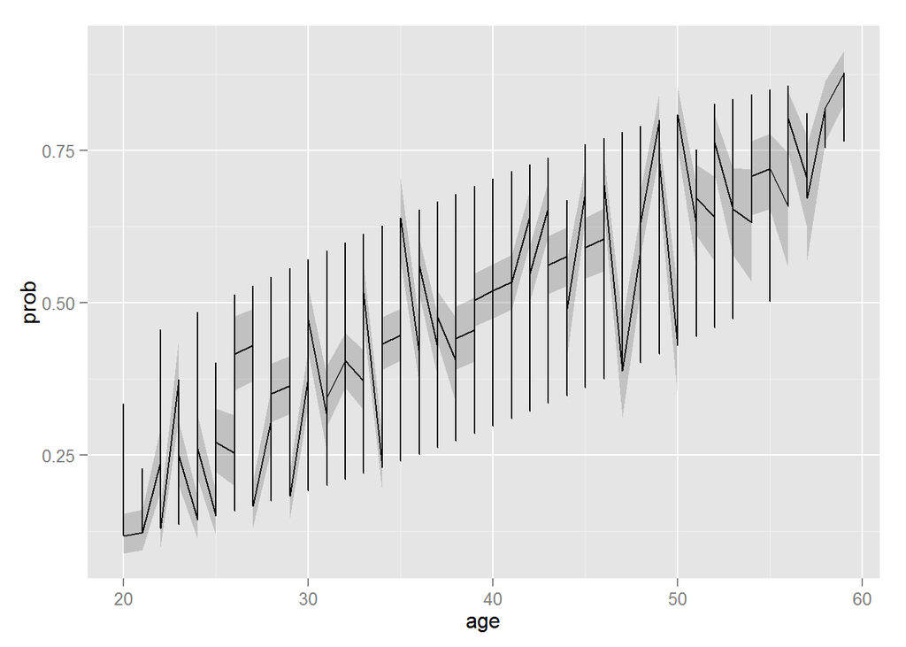

```r
# применив логистическую функцию распределения получим границы доверительного интервала
newdata_pr <- mutate(newdata_pr,prob=plogis(fit),
                     left_ci=plogis(fit-1.96*se.fit),
                     right_ci=plogis(fit+1.96*se.fit))

# посмотрим на графике как меняется доверительный интервал для вероятности
qplot(data=newdata_pr,x=age,y=prob,geom="line") +
  geom_ribbon(aes(ymin=left_ci,ymax=right_ci),alpha=0.2)
```

Построим обычную линейную регерссию методом МНК:

```r
# обычный МНК
m_ols <- lm(data=women, as.numeric(work)~age + education + married + children)
summary(m_ols)
```

```
##
## Call:
## lm(formula = as.numeric(work) ~ age + education + married + children,
##     data = women)
##
## Residuals:
##     Min      1Q  Median      3Q     Max
## -1.0703 -0.4142  0.1372  0.3437  0.8060
##
## Coefficients:
##             Estimate Std. Error t value Pr(>|t|)
## (Intercept) 0.792677   0.054111  14.649  < 2e-16 ***
## age         0.010255   0.001227   8.358  < 2e-16 ***
## education   0.018601   0.003250   5.724 1.20e-08 ***
## married1    0.111112   0.021948   5.063 4.52e-07 ***
## children    0.115308   0.006772  17.028  < 2e-16 ***
## ---
## Signif. codes:  0 '***' 0.001 '**' 0.01 '*' 0.05 '.' 0.1 ' ' 1
##
## Residual standard error: 0.4199 on 1995 degrees of freedom
## Multiple R-squared:  0.2026, Adjusted R-squared:  0.201
## F-statistic: 126.7 on 4 and 1995 DF,  p-value: < 2.2e-16
```

```r
# прогнозы по обычному МНК
pr_ols <- predict(m_ols,newdata_women)
head(pr_ols)
```

```
##        1        2        3        4        5        6
## 1.315415 1.458988 1.376946 1.469243 1.489753 1.428222
```

мы уже видим, что веростность не лежат в промежутке от 0 до 1. Поэтому мы используем логит и пробит модели. Однако, нам дали вероятность в промежутке, а не 0 или 1. Там нужно точное значение, попытаемся выбрать порог прогнозирования с помошью ROC-кривой.

```r
# ROC кривая
# спрогнозируем скрытую переменную для исходного набора данных
pr_t <- predict(m_logit,women,se=TRUE)
# соединим прогнозы с исходным набором данных
women <- cbind(women,pr_t)
# применим логистическую функцию распределения, чтобы получить вероятности
women <- mutate(women,prob=plogis(fit))


# получим все данные для ROC кривой:
roc.data <- roc(women$prob,women$work)
str(roc.data)
```

```
## List of 3
##  $ cutoffs: num [1:784] 1 0.995 0.994 0.993 0.992 ...
##  $ fpr    : num [1:784] 0 0 0 0 0 0 0 0 0 0 ...
##  $ tpr    : num [1:784] 0 0.000745 0.001489 0.002978 0.003723 ...
##  - attr(*, "class")= chr [1:2] "AUC" "roc"
```

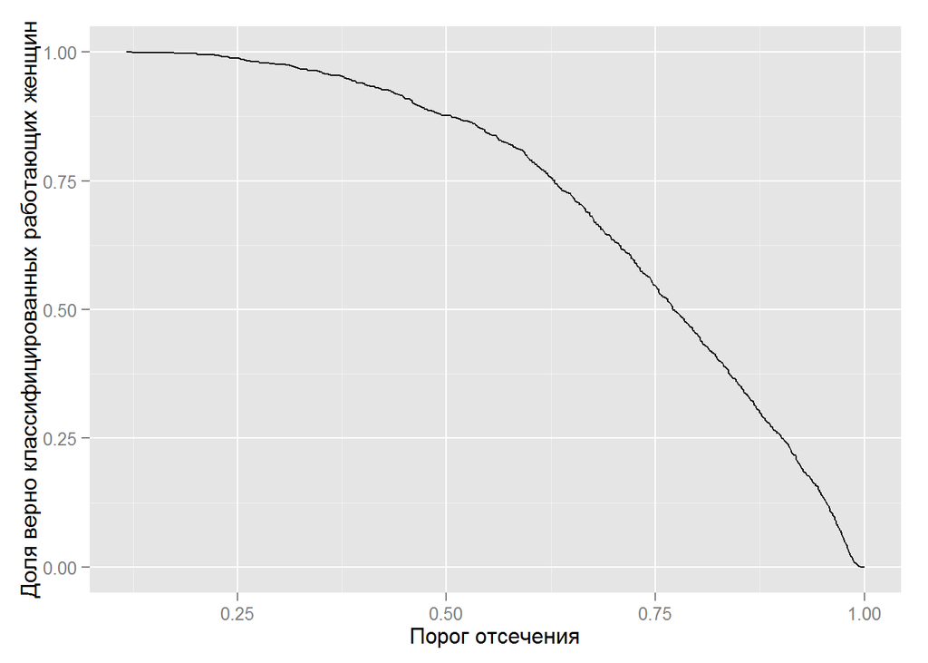

```r
# три графика для выбора порога отсечения
# по горизонтали --- пороги, по вертикали --- чувствительность
# чувствительность = число верно предсказанных значений / общее количество женщин
qplot(x=roc.data$cutoffs,y=roc.data$tpr,geom="line", xlab = "Порог отсечения", ylab = 'Доля верно классифицированных работающих женщин')
```

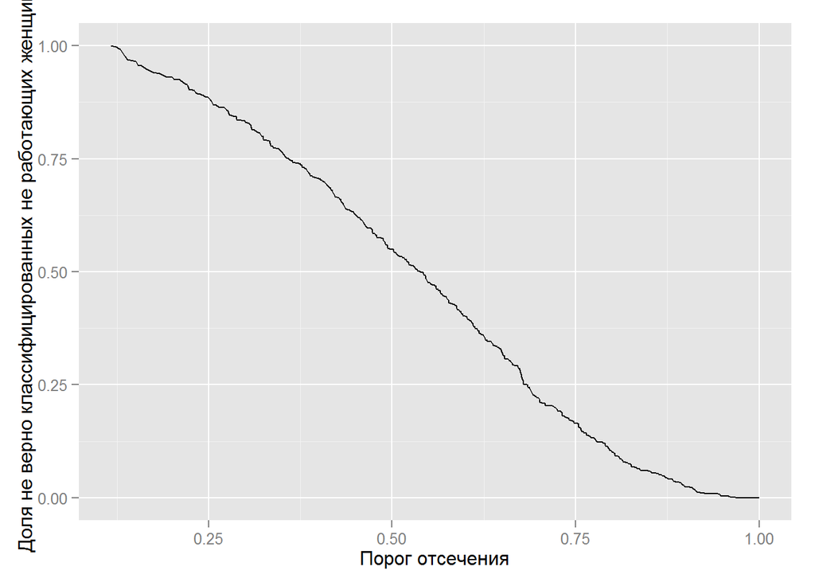

```r
# по горизонтали --- пороги, по вертикали --- процент ложноположительных прогнозов
# процент ложно положительных прогнозов =
# число не работающих ошибочно предсказанных работающих/общее число женщин
qplot(x=roc.data$cutoffs,y=roc.data$fpr,geom="line", xlab = "Порог отсечения", ylab = 'Доля не верно классифицированных не работающих женщин')
```

[figure not shown]

```r
# по горизонтали --- процент ложноположительных прогнозов
# по вертикали --- чувствительность
qplot(x=roc.data$fpr,y=roc.data$tpr,geom="line", xlab = "Доля верно классифицированных работающих женщин", ylab = 'Доля не верно классифицированных не работающих женщин', main='ROC кривая')
```

Увеличения уровня отсечения, как правило, приводит к тому, что доля верно классифицированных работающих женщин и доля неверно классифицированных неработающих женщин падает.